# Antibiotic susceptibility in respiratory Pseudomonas aeruginosa

Basel laboratory data, 2015-2018. This analysis estimates ciprofloxacin susceptibility conditional on piperacillin-tazobactam results and the added coverage of the pair. S = susceptible; NS = nonsusceptible.

## Data preparation

The shared script reads pinned public files and collapses repeated measurements to one result per laboratory order. Mixed or conflicting clear results are unclassified; see `scripts/prepare_data.R` for the cleaning code.

```r
knitr::opts_chunk$set(echo = TRUE, message = FALSE, fig.width = 7,
                      fig.height = 4.5, dpi = 200,
                      fig.path = "outputs/figures/main_")
source("scripts/prepare_data.R")
prepared <- prepare_data()
orders <- prepared$order_data

drugs <- c("Piperacillin-tazobactam", "Ciprofloxacin")
eligible <- orders[complete.cases(orders[, drugs]), ]
samples <- first_eligible(orders, drugs)
samples$pip_NS <- samples$`Piperacillin-tazobactam` == 1
samples$cipro_S <- samples$Ciprofloxacin == 0

knitr::kable(data.frame(
  Stage = c("Respiratory orders", "Both results available", "First eligible order per patient-year"),
  N = c(nrow(orders), nrow(eligible), nrow(samples))))
```

| Stage | N |
| --- | --- |
| Respiratory orders | 640 |
| Both results available | 605 |
| First eligible order per patient-year | 350 |

The analysis keeps each patient’s first eligible order per year, giving 350 patient-year observations. Patient labels cannot be linked across years.

## Joint and conditional probabilities

```r
joint <- table(
  Pip_tazo = factor(samples$pip_NS, levels = c(FALSE, TRUE), labels = c("S", "NS")),
  Cipro = factor(samples$cipro_S, levels = c(TRUE, FALSE), labels = c("S", "NS")))
knitr::kable(addmargins(joint))
```

|  | S | NS | Sum |
| --- | --- | --- | --- |
| S | 253 | 41 | 294 |
| NS | 34 | 22 | 56 |
| Sum | 287 | 63 | 350 |

```r
A <- samples$pip_NS
B <- samples$cipro_S
N <- nrow(samples)
M <- sum(A)
Y <- sum(A & B)
```

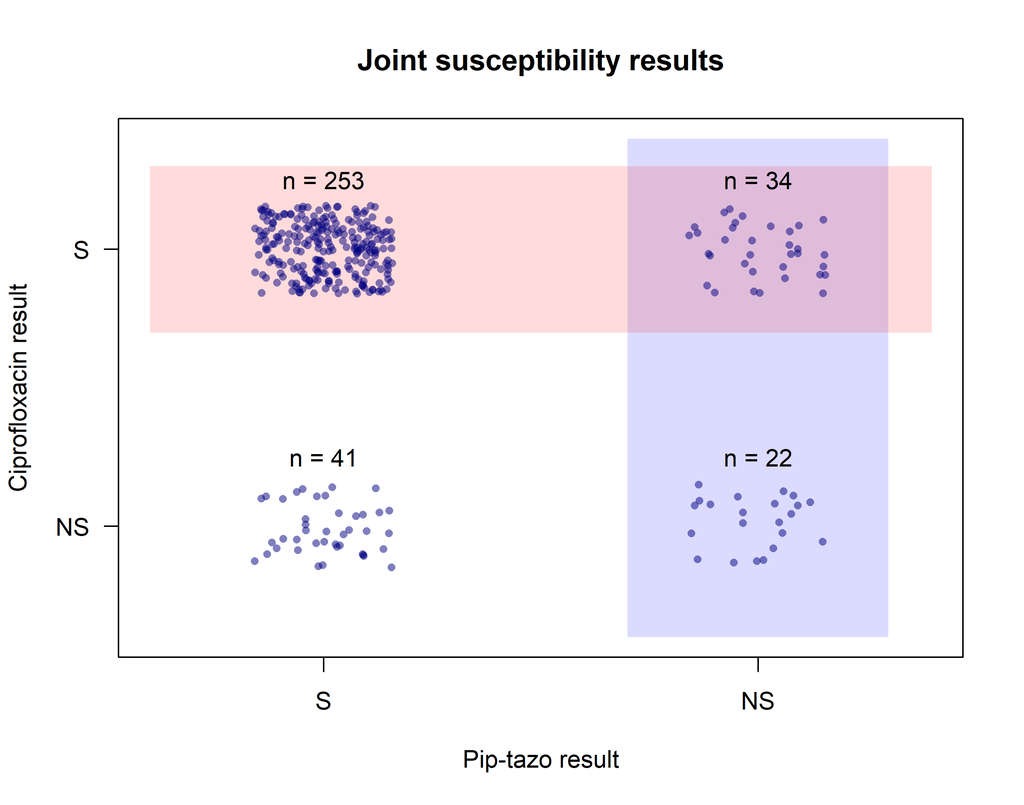

```r
set.seed(651)
x <- jitter(as.integer(A), amount = 0.16)
y <- jitter(as.integer(B), amount = 0.16)

plot(x, y, type = "n", xlim = c(-0.4, 1.4), ylim = c(-0.4, 1.4),
     axes = FALSE, xlab = "Pip-tazo result", ylab = "Ciprofloxacin result",
     main = "Joint susceptibility results")
rect(0.7, -0.4, 1.3, 1.4, col = adjustcolor("blue", 0.14), border = NA)
rect(-0.4, 0.7, 1.4, 1.3, col = adjustcolor("red", 0.14), border = NA)
points(x, y, pch = 16, cex = 0.7, col = adjustcolor("navy", 0.5))
axis(1, at = 0:1, labels = c("S", "NS"))
axis(2, at = 0:1, labels = c("NS", "S"), las = 1)
box()
text(c(0, 1, 0, 1), c(0.25, 0.25, 1.25, 1.25),
     labels = paste("n =", c(joint["S", "NS"], joint["NS", "NS"],
                             joint["S", "S"], joint["NS", "S"])))
```

The vertical blue band is A = pip-tazo NS; the horizontal red band is B = cipro S. Their overlap contains 34 samples; jitter only separates points and all probabilities use the original binary results.

```r
overall <- mean(B)
given_pip_S <- mean(B[!A])
q_hat <- mean(B[A])
probabilities <- data.frame(
  Group = c("All samples", "Pip-tazo S", "Pip-tazo NS"),
  Cipro_S = c(sum(B), sum(B & !A), Y),
  Total = c(N, sum(!A), M),
  Probability = c(overall, given_pip_S, q_hat))
knitr::kable(probabilities, digits = 3)
```

| Group | Cipro_S | Total | Probability |
| --- | --- | --- | --- |
| All samples | 287 | 350 | 0.820 |
| Pip-tazo S | 253 | 294 | 0.861 |
| Pip-tazo NS | 34 | 56 | 0.607 |

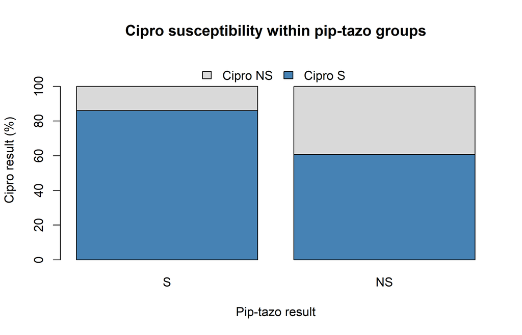

```r
proportions <- prop.table(t(joint), margin = 2)
barplot(100 * proportions, col = c("steelblue", "grey85"),
        ylim = c(0, 115), xlab = "Pip-tazo result", ylab = "Cipro result (%)",
        main = "Cipro susceptibility within pip-tazo groups",
        legend.text = c("Cipro S", "Cipro NS"),
        args.legend = list(x = "top", horiz = TRUE, bty = "n"))
```

Cipro was S in 82% of all samples and 60.7% of pip-tazo NS samples (34/56).

## Added coverage

P(A and B) = P(A) P(B given A). Added coverage uses all N samples as its denominator, while conditional rescue uses the M samples missed by pip-tazo.

```r
r_hat <- M / N
added <- Y / N
first_coverage <- mean(!A)
combined_coverage <- mean(!A | B)

coverage <- data.frame(
  Quantity = c("Pip-tazo S", "Cipro S given pip-tazo NS", "Added coverage", "Combined coverage"),
  Numerator = c(sum(!A), Y, Y, sum(!A | B)),
  Denominator = c(N, M, N, N),
  Percent = 100 * c(first_coverage, q_hat, added, combined_coverage))
knitr::kable(coverage, digits = 1)
```

| Quantity | Numerator | Denominator | Percent |
| --- | --- | --- | --- |
| Pip-tazo S | 294 | 350 | 84.0 |
| Cipro S given pip-tazo NS | 34 | 56 | 60.7 |
| Added coverage | 34 | 350 | 9.7 |
| Combined coverage | 328 | 350 | 93.7 |

```r
knitr::kable(data.frame(
  Method = c("Assuming independent drug results", "Observed joint results"),
  Added_points = 100 * c(r_hat * overall, added)), digits = 1)
```

| Method | Added_points |
| --- | --- |
| Assuming independent drug results | 13.1 |
| Observed joint results | 9.7 |

The pair covered 93.7% of samples, an increase of 9.7 percentage points. Assuming independence would overestimate the observed gain.

## Maximum likelihood

Model M as Binomial(N, r) and Y given M as Binomial(M, q); the MLEs are r = M/N and q = Y/M. This assumes approximately independent patient-year observations with common probabilities across the period.

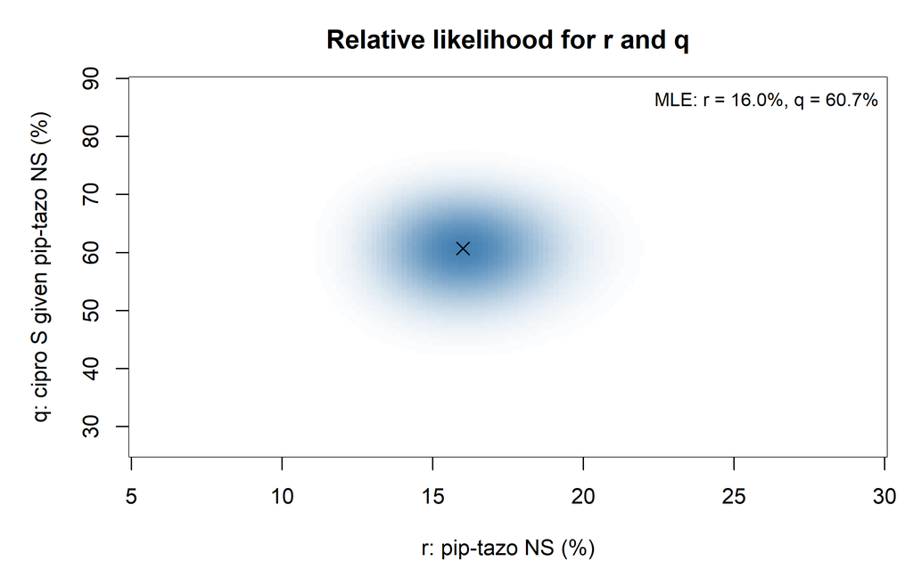

```r
r_values <- seq(0.05, 0.30, length.out = 150)
q_values <- seq(0.25, 0.90, length.out = 150)
log_likelihood <- outer(dbinom(M, N, r_values, log = TRUE),
                        dbinom(Y, M, q_values, log = TRUE), "+")
maximum <- dbinom(M, N, r_hat, log = TRUE) + dbinom(Y, M, q_hat, log = TRUE)
relative_likelihood <- exp(log_likelihood - maximum)

par(mar = c(5, 5, 3, 1))
image(100 * r_values, 100 * q_values, relative_likelihood,
      col = colorRampPalette(c("white", "steelblue"))(50),
      xlab = "r: pip-tazo NS (%)", ylab = "q: cipro S given pip-tazo NS (%)",
      main = "Relative likelihood for r and q")
points(100 * r_hat, 100 * q_hat, pch = 4, cex = 1.3)
legend("topright", sprintf("MLE: r = %.1f%%, q = %.1f%%", 100*r_hat, 100*q_hat),
       bty = "n", cex = 0.85)
```

Darker cells have higher likelihood relative to the maximum; the cross marks the MLE. The colors describe fit to the observed counts, not probabilities that the parameter values are true.

## Scope

Coverage describes historical laboratory susceptibility, not clinical recovery or treatment effects. Missing testing, selection of eligible samples, and unlinked patient labels across years limit generalization.